# Problems

## Problem 1

Find the impedance of the following circuit. Assuming that $v(t)=V_{p} \cos \omega t$, find the expression of current. Find the resonance frequency of the circuit.

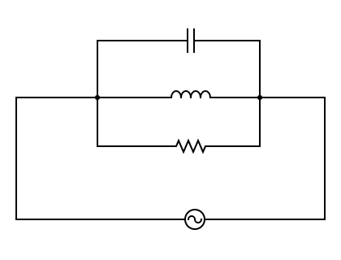

**Solution**: the three components are in parallel, so we can write

$$\frac{1}{Z}=\frac{1}{Z_1}+\frac{1}{Z_2}+\frac{1}{Z_3}=\frac{1}{R}+\frac{1}{j\omega L}+\frac{1}{(1/(j\omega C)}$$

Then,

$$\frac{1}{Z}=\frac{1}{R}+\frac{-j}{\omega L}+j\omega C=\frac{1}{R}+j(\omega C-\frac{1}{\omega L})$$

Finally, the impedance is

$$Z=\frac{1}{\frac{1}{R}+j(\omega C-\frac{1}{\omega L})}=\frac{\frac{1}{R}-j(\omega C-\frac{1}{\omega L})}{\frac{1}{R^2}+(\omega C-\frac{1}{\omega L})^2}$$

The current will be of the form $i(t)=I_{p} \cos (\omega t+\varphi)$, where

$$I_{p}=\frac{V_p}{|Z|}=V_p\frac{1}{|Z|}=V_p\sqrt{\frac{1}{R^2}+(\omega C-\frac{1}{\omega L})^2}$$

$$ \varphi=-\arctan \frac{\operatorname{Im}(Z)}{\operatorname{Re}(Z)}=\arctan \left((\omega C-\frac{1}{\omega L})R\right) $$

Resonance occurs when $$ L \omega=\frac{1}{\omega C} \Rightarrow \omega_{res}=\sqrt{\frac{1}{L C}} $$

at which current reaches a **minimum** (contrary to a RLC circuit in series!)

## Problem 2

Find the impedance of the following circuit. Assuming that $v(t)=V_{p} \cos \omega t$, find the expression of the peak current current $I_p$. Find the resonance frequency of the circuit.

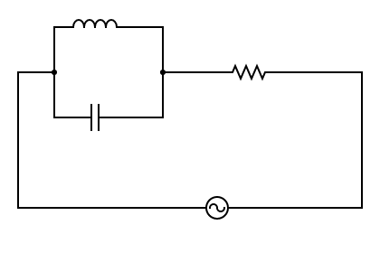

**Solution**: **Solution**: the inductor and capacitor are in parallel, so we can write

$$\frac{1}{Z}=\frac{1}{Z_1}+\frac{1}{Z_2}=\frac{1}{j\omega L}+\frac{1}{(1/(j\omega C)}$$

Then,

$$\frac{1}{Z}=\frac{-j}{\omega L}+j\omega C=j(\omega C-\frac{1}{\omega L})$$

The impedance would be

$$Z=\frac{1}{j(\omega C-\frac{1}{\omega L})}=\frac{-j}{(\omega C-\frac{1}{\omega L})}$$

This impedance is now in series with the resistor, so the final impedance is

$$Z=R-j\frac{1}{(\omega C-\frac{1}{\omega L})}$$

The current will be of the form $i(t)=I_{p} \cos (\omega t+\varphi)$, where

$$I_{p}=\frac{V_p}{|Z|}=\frac{V_p}{\sqrt{{R^2}+\frac{1}{(\omega C-\frac{1}{\omega L})^2}}}\\ =\frac{V_p}{\sqrt{{R^2}+\frac{\omega^2L^2}{(\omega^2 LC-1)^2}}}$$

Resonance occurs when $$(\omega^2 LC-1)=0\implies \omega=\frac{1}{\sqrt{LC}}$$, at which $I_p\rightarrow 0$

## Problem 3

Find the impedance of the following circuit and the power dissipated knowing that it is powered by an alternating voltage $v(t)=220V\cos(2\pi (50Hz)t)$

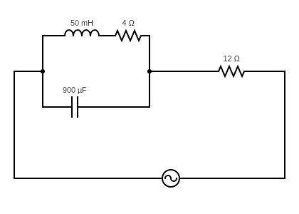

**Solution**:

First of all, $\omega=2\pi f=2\pi 50=314.16 rad/s$.

$${Z}_{aux1}=R1+j(\omega L)=(4+15.7j)\Omega$$

This is in parallel with the capacitor so

$${Z}_{aux2}=Z_1*Z2/(Z_1+Z_2)=(0.31-4.46j)\Omega$$

The final impedance is obtained by combining the previous one with the last resistor in series,

$${Z}=Z_{aux2}+R2=(12.31-4.46j)\Omega$$

In other words,

$$|Z|=13.1\Omega$$$$\phi=19.94º$$

The peak current is $$I_p=V_p/|Z|=16.8A$$, and the power dissipated $$P=\frac{1}{2}V_pI_p\cos(\phi)=1.7kW$$

```python
import numpy as np
omega=2*np.pi*50
L=50*10**(-3)
C=900*10**(-6)
R1=4
R2=12
```

```python
omega
```

```
314.1592653589793
```

```python
omega*L
```

```
15.707963267948967
```

```python
Zaux1=(4+15.7j)
Zcap=complex(0,-1/(omega*C))
Zaux2=Zaux1*Zcap/(Zaux1+Zcap)
Zaux2
```

```
(0.3051965958474903-4.464820113832698j)
```

```python
Z=Zaux2+R2
Z
```

```
(12.305196595847491-4.464820113832698j)
```

```python
abs(Z)
```

```
13.090167375222583
```

```python
phi=-np.degrees(np.arctan(Z.imag/Z.real))
phi
```

```
19.94280741262228
```

```python
Ip=220/abs(Z)
Ip
```

```
16.806507792743876
```

```python
P=0.5*220*Ip*np.cos(-np.arctan(Z.imag/Z.real))
P
```

```
1737.854942618132
```

## Problem 4

Find the voltage gain $A_{V}=\frac{\left|V_{\text {out }}\right|}{\left|V_{\text {in }}\right|}$ in the following circuit. What kind of filter is it?

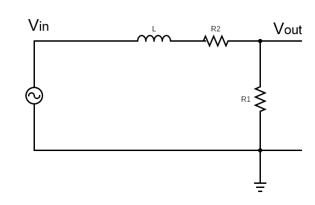

**Solution**:

Applying Kirchoff and the generalized Ohm's law,

$$V_{in}=(R_1+R_2+j \omega L)I $$$$V_{out}=R_1I $$

Hence, $$ A_{V}=\frac{|V_{o u t}|}{|V_{i n}|}=\frac{R_1}{\sqrt{(R_1+R_2)^2+(\omega L)^2}}$$

Let us re-express the previous gain more beautifully by defining $\omega_0=\frac{R1+R2}{L}$, so that

$$A_{V}=\frac{R_1}{(R_1+R_2)}\frac{1}{\sqrt{1+(\frac{\omega L}{R1+R2})^2}}=\frac{R_1}{(R_1+R_2)}\frac{1}{\sqrt{1+(\frac{\omega}{\omega_0})^2}} $$

Then we can see it acts as a low-pass filter since

- If $\omega \gg \omega_0\implies A_V\rightarrow 0$
- If $\omega \ll \omega_0\implies A_V\rightarrow \frac{R_1}{(R_1+R_2)}$
- If $\omega = \omega_0\implies A_V=\frac{R_1}{\sqrt{2}(R_1+R_2)}$

## Problem 5

Find the voltage gain $A_{V}=\frac{\left|V_{\text {out }}\right|}{\left|V_{\text {in }}\right|}$ in the following circuit, knowing that the voltage frequency is $f=50Hz$.

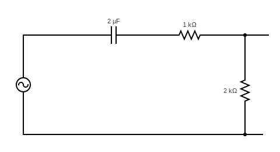

Applying Kirchoff and the generalized Ohm's law,

$$V_{in}=(R_1+R_2-j \frac{1}{\omega C})I $$$$V_{out}=R_1I $$

Hence, $$ A_{V}=\frac{|V_{o u t}|}{|V_{i n}|}=\frac{R_1}{\sqrt{(R_1+R_2)^2+(\frac{1}{\omega C})^2}}=0.59$$

```python
f=50
w=2*np.pi*f
R1=2*10**3
R2=1*10**3
C=2*10**(-6)
Zcap=complex(0,-1/(w*C))
```

```python
Z_aux=R1+R2+Zcap
Z_aux
```

```
(3000-1591.5494309189535j)
```

```python
Av=R1/Z_aux
abs(Av)
```

```
0.5889226972822662
```